# ACTG175 Binary Harm Search: Single-Data Analysis

ForestSearch with GLM Odds-Ratio Outcome (Dual-Scale Framing)

Author

Larry F. León

Published

May 15, 2026

# 1 To-do

- Extend FS to cut continuous factors in *J* non-overlapping intervals (e.g., J = 12 to allow for fuller exploration)
- Save results
- Outcome construction and BL in table (not scattered sprintf)
- Clean up scattered printing

# 2 Introduction

This vignette demonstrates the **ForestSearch** methodology for exploratory subgroup identification with a **binary outcome on the odds-ratio (OR) scale**, applied to the ACTG175 trial. It uses the GLM extension of ForestSearch (León et al. 2024 *Statistics in Medicine*) and is the binary-outcome counterpart to the continuous-outcome vignette.

## 2.1 Motivation

Many randomized trials have binary endpoints (response, improvement, event-by-time-point indicators) where the natural treatment-effect contrast is the odds ratio between arms. ForestSearch identifies subgroups where the treatment effect deviates meaningfully from a prespecified threshold, with proper accounting for the optimism inherent in data-driven subgroup discovery.

## 2.2 Methodology Overview — Dual-Scale Framing

**Note**

**ForestSearch vs GRF**: The forestsearch methodology was developed for survival data where the outcome is generally the timing to an adverse outcome and thresholds (e.g., indicative of harm) were defined accordingly. In contrast, GRF evaluates data in terms of benefit where thresholds are defined as `benefit in favor of control`. The dual-scale framing is simply a matter of aligning the threshold directions (for harm) to the forestsearch and GRF interpretations.

This analysis applies **two different methods** on **two different scales of the same binary outcome**:

- **Part I — ForestSearch on the adverse scale** (`y_binary_neg = 1 - y_binary_pos`, indicator of NO CD4 improvement; 1 = worse). With `adverse_outcome = TRUE`, an OR above the screening threshold indicates harm (the treatment increases the odds of no improvement).
- **Part II — GRF standalone on the beneficial scale** (`y_binary_pos = I(cd420 > cd40)`, indicator of CD4 improvement; 1 = better). With the default `adverse_outcome = FALSE`, a CATE below the threshold indicates harm (insufficient improvement).
- **Part III — Cross-method comparison**: per-subject H/Hc agreement between the two analyses, with Cohen’s κ.

The two scales are sign-flipped versions of the same binary outcome (`y_binary_neg = 1 - y_binary_pos`), so the ITT log-odds-ratios are equal in magnitude with opposite signs. Differences in identified subgroups reflect the methods (FS exhaustive search vs GRF policy tree) and the model class, not the data.

## 2.3 Trial Background

- **Arm 1**: ZDV + ddI combination therapy (treatment, T = 1)
- **Arm 3**: ddI monotherapy (control, T = 0)

# 3 Setup

## 3.1 Load Required Packages

```r
library(forestsearch)
library(speff2trial)
library(survival)
library(data.table)
library(ggplot2)
library(gt)
library(grf)
library(policytree)
library(doFuture)
library(future)
library(patchwork)
library(forestploter)

# Set ggplot theme
theme_set(theme_minimal(base_size = 12))
```

## 3.2 Analysis Parameters

```r
# ─── Parallel processing ────────────────────────────────────────────────
n_cores <- max(1L, floor(0.95 * parallel::detectCores(logical = FALSE)))

# ─── Reproducibility ────────────────────────────────────────────────────
analysis_seed <- 8316951L
set.seed(analysis_seed)

# ─── Confounders ───────────────────────────────────────────────────────
cont_vars <- c("age", "preanti", "wtkg", "karnof", "cd40", "cd80")
bin_vars  <- c("hemo", "homo", "drugs", "race", "gender", "symptom")
confounders.name <- c(cont_vars, bin_vars)
id.name <- "id"

# ─── Variables (dual-scale framing) ────────────────────────────────────
treat.name         <- "treat"
adverse_outcome    <- "y_binary_neg"   # FS adverse-scale outcome
beneficial_outcome <- "y_binary_pos"   # GRF beneficial-scale outcome

# ─── ForestSearch parameters (binary, OR scale) ────────────────────────
fs_outcome_type    <- "binary"
fs_effect_measure  <- "OR"

fs_sg_focus        <- "effMaxSG"   # GLM-natural alias for "hrMaxSG" (see
                                   # NEWS for the effect-vocabulary aliases)
fs_selection_rule  <- "both"   # candidate inclusion: neighborhood ∩ Pareto
                               # (only used by effMaxSG / effMinSG focus)

# Thresholds on the OR scale (adverse scale: OR > c1 = harm)
fs_or_threshold    <- 1.25  # screening: OR >= 1.25 indicates harm
fs_or_consistency  <- 1.0   # consistency: OR >= 1.0 (nominal harm)

fs_pconsistency    <- 0.90
fs_n_min           <- 60L
fs_d0_min          <- 10L
fs_d1_min          <- 10L
fs_splits          <- 500L
fs_max_subgroups   <- 20
fs_maxk            <- 2L
fs_use_lasso       <- TRUE
fs_use_grf         <- TRUE
fs_is_RCT          <- TRUE
fs_vi_grf_min      <- -0.2
fs_dmin_grf        <- 0
fs_cont_cutoff     <- 4L

# ─── Pareto-frontier diagnostic parameters ──────────────────────────────
# Drives compute_frontier_cis(), plot_pareto_frontier(),
# pareto_frontier_table(), and explain_pareto_selection() in the
# post-hoc selection diagnostic section.
# NB: with sg_focus = "effMaxSG" and selection_rule = "both", the rule
# selects from the intersection of the effect-size neighborhood (within
# `effect_neighborhood` of the maximum) and the Pareto-non-dominated set
# on (effect, N).  The selected subgroup is typically a frontier member.
# The frontier is shown here both as the selection criterion AND as a
# diagnostic of the candidate trade-off space.
# For OR (ratio-scale), the effect axis is auto-rendered on log scale
# by plot_pareto_frontier(); leave xlim = NULL for auto bounds.
frontier_params <- list(
  n_splits      = 1000L,
  seed          = 1L,
  xlim          = c(0.35,10),       # auto (OR auto-detected as ratio scale)
  digits        = 2L
)

# ─── GRF standalone parameters (beneficial scale) ──────────────────────
grf_outcome_type   <- "binary"
grf_effect_measure <- "OR"
grf_dmin_grf       <- 0.1    # on the RD scale for binary outcomes
                             # (e.g., 0.10 = 10 percentage-point absolute
                             # difference in event rates)
grf_maxdepth       <- 2L
grf_RCT            <- TRUE
grf_sg_criterion   <- "mDiff"
grf_tune           <- FALSE

# ─── Bootstrap (gated; demo by default) ────────────────────────────────
run_bootstrap <- TRUE
NB <- 20L     # PRESSURE-TEST DEMO. Set to 500-2000 for production.

# ─── Cross-Validation (gated; demo by default) ─────────────────────────
run_cv <- TRUE
Kfolds_cv <- 3L  # PRESSURE-TEST DEMO. 10-fold CV. For LOO, set to nrow(fs_result$df.est).
                  # Production: 10-fold is standard; consider forestsearch_tenfold()
                  # with sims = 50-100 for repeated K-fold stability assessment.

# ─── Leave-One-Out CV (gated; demo by default) ─────────────────────────
# LOO runs forestsearch() once per observation (N folds).  Comparable in
# cost to K-fold * N/K, but well-tolerated on samples up to ~1000.
# Set FALSE to skip; toggles independently of run_cv.
run_loo <- FALSE

# ─── Numeric Precision ─────────────────────────────────────────────────
# Two-stage precision control (Reading-C design):
# - construction_digits: upstream sprintf precision in the bootstrap and
#   CV table builders. Acts as a CEILING for downstream display: values
#   rounded here cannot be recovered later. Default 4 provides headroom.
# - display_digits: precision rendered in user-facing tables.
#   summarize_bootstrap_results() parses construction-time strings and
#   reformats at this precision, which must be <= construction_digits.
#   sg_tables() applies it via ndecimals; cv_summary_tables() applies
#   it via digits.
construction_digits <- 2L
display_digits      <- 2L

# ─── Combined Forest Plot ──────────────────────────────────────────────
# Capstone visualization that integrates fs_result, fs_bc (if bootstrap),
# and fs_kfold_result (if CV).  Always rendered; CV/bootstrap annotations
# appear conditionally on the run_* flags.
run_forestplot <- TRUE
```

# 4 Data Preparation

## 4.1 Treatment Assignment

```r
# ACTG175: arm 1 = ZDV+ddI (experimental), arm 3 = ddI (control)
actg_df <- subset(speff2trial::ACTG175, arms %in% c(1L, 3L))
actg_df$id <- seq_len(nrow(actg_df))

# Treatment: ZDV+ddI = 1, ddI = 0 (NO switching)
actg_df$treat <- ifelse(actg_df$arms == 1L, 1L, 0L)
```

## 4.2 Outcome Construction

```r
# Drop subjects missing the week-20 CD4 measurement
actg_df <- actg_df[!is.na(actg_df$cd420), ]

# Beneficial scale: CD4 improvement indicator (1 = improved, higher = better)
actg_df$y_binary_pos <- as.integer(actg_df$cd420 > actg_df$cd40)

# Adverse scale: NO improvement indicator (1 = did not improve, higher = worse)
actg_df$y_binary_neg <- 1L - actg_df$y_binary_pos

outcome_vars <- c("y_binary_neg", "y_binary_pos")
```

## 4.3 Covariates

```r
# Coerce binary indicators to factors (analyst does not know true cuts
# for continuous covariates; ForestSearch handles those internally)
for (v in bin_vars) actg_df[[v]] <- as.factor(actg_df[[v]])

cat("Continuous candidates:", paste(cont_vars, collapse = ", "), "\n")
```

```
#> Continuous candidates: age, preanti, wtkg, karnof, cd40, cd80
```

```r
cat("Binary candidates:    ", paste(bin_vars, collapse = ", "), "\n")
```

```
#> Binary candidates:     hemo, homo, drugs, race, gender, symptom
```

## 4.4 Baseline Characteristics

```r
create_summary_table(
  data = actg_df,
  treat_var = treat.name,
  table_title = "ACTG175 Baseline Characteristics and Outcomes by Treatment Arm",
  vars_continuous = c(outcome_vars,cont_vars),
  vars_categorical = bin_vars,
  font_size = 12
)
```

ACTG175 Baseline Characteristics and Outcomes by Treatment Arm

| Characteristic |  | Control (n=561) | Treatment (n=522) | P-value<sup>1</sup> | SMD<sup>2</sup> |
| --- | --- | --- | --- | --- | --- |
| y_binary_neg | Mean (SD) | 0.4 (0.5) | 0.3 (0.5) | 0.001 | 0.20 |
| y_binary_pos | Mean (SD) | 0.6 (0.5) | 0.7 (0.5) | 0.001 | 0.20 |
| age | Mean (SD) | 35.1 (8.5) | 35.2 (8.7) | 0.828 | 0.01 |
| preanti | Mean (SD) | 383.9 (477.7) | 379.1 (474.0) | 0.870 | 0.01 |
| wtkg | Mean (SD) | 74.9 (13.0) | 74.9 (13.6) | 0.988 | 0.00 |
| karnof | Mean (SD) | 95.1 (5.9) | 95.5 (5.8) | 0.258 | 0.07 |
| cd40 | Mean (SD) | 347.5 (114.4) | 348.7 (130.2) | 0.866 | 0.01 |
| cd80 | Mean (SD) | 971.9 (502.7) | 1004.3 (488.0) | 0.282 | 0.07 |
| hemo |  | 49 (8.7%) | 43 (8.2%) | 0.854 | 0.02 |
| homo |  | 379 (67.6%) | 346 (66.3%) | 0.703 | 0.03 |
| drugs |  | 69 (12.3%) | 73 (14.0%) | 0.465 | 0.05 |
| race |  | 173 (30.8%) | 138 (26.4%) | 0.125 | 0.10 |
| gender |  | 470 (83.8%) | 434 (83.1%) | 0.841 | 0.02 |
| symptom |  | 96 (17.1%) | 96 (18.4%) | 0.638 | 0.03 |

<sup>1</sup> P-values: t-test for continuous, chi-square/Fisher's exact for categorical/binary variables  
<sup>2</sup> SMD = Standardized mean difference (Cohen's d for continuous, Cramer's V for categorical)

## 4.5 ITT Analysis

```r
# Adverse-scale ITT OR (y_binary_neg = no improvement; OR > 1 = treatment
# increases the odds of no improvement = harm)
itt_neg <- glm(y_binary_neg ~ treat, data = actg_df, family = binomial)

# Beneficial-scale ITT OR (y_binary_pos = improvement; OR > 1 = treatment
# increases the odds of improvement = benefit)
itt_pos <- glm(y_binary_pos ~ treat, data = actg_df, family = binomial)

# Helper to print OR / log-OR / 95% CI / p-value
print_or <- function(fit, label) {
  beta  <- coef(fit)["treat"]
  se    <- summary(fit)$coefficients["treat", "Std. Error"]
  z     <- beta / se
  p     <- 2 * pnorm(-abs(z))
  or    <- exp(beta)
  ci_lo <- exp(beta - qnorm(0.975) * se)
  ci_hi <- exp(beta + qnorm(0.975) * se)
  cat(sprintf("=== ITT Odds Ratio, %s ===\n", label))
  cat(sprintf("  log-OR (treat): %7.4f  (SE %.4f)\n", beta, se))
  cat(sprintf("  OR:             %6.3f  (95%% CI: %.3f, %.3f)\n",
              or, ci_lo, ci_hi))
  cat(sprintf("  p-value:        %.4f\n", p))
}

print_or(itt_neg, "adverse scale (y_binary_neg)")
```

```
#> === ITT Odds Ratio, adverse scale (y_binary_neg) ===
#>   log-OR (treat): -0.4078  (SE 0.1252)
#>   OR:              0.665  (95% CI: 0.520, 0.850)
#>   p-value:        0.0011
```

```r
cat("\n")
```

```r
print_or(itt_pos, "beneficial scale (y_binary_pos)")
```

```
#> === ITT Odds Ratio, beneficial scale (y_binary_pos) ===
#>   log-OR (treat):  0.4078  (SE 0.1252)
#>   OR:              1.504  (95% CI: 1.176, 1.922)
#>   p-value:        0.0011
```

```r
cat("\nNote: y_binary_neg = 1 - y_binary_pos, so the two log-ORs are\n")
```

```
#>
#> Note: y_binary_neg = 1 - y_binary_pos, so the two log-ORs are
```

```r
cat("equal in magnitude with opposite signs (likewise the two ORs are\n")
```

```
#> equal in magnitude with opposite signs (likewise the two ORs are
```

```r
cat("reciprocals of each other).\n")
```

```
#> reciprocals of each other).
```

# 5 Part I: ForestSearch (Adverse Scale)

## 5.1 Rationale

ForestSearch operates on the adverse scale (`y_binary_neg`, indicator of NO improvement) with `adverse_outcome = TRUE`. An OR above `fs_or_threshold` indicates the treatment **increases the odds of no improvement** in that subgroup (harm). No outcome flip is applied; the screening threshold is on the OR scale directly.

## 5.2 ForestSearch Parameters

**Note**

**API note: GLM-natural vocabulary.** This template uses the GLM-natural parameter names introduced in forestsearch 0.2.0:

- `sg_focus = "effMaxSG"` (alias for the legacy `"hrMaxSG"`)
- `effect.threshold` (alias for `hr.threshold`)
- `consistency.threshold` (alias for `hr.consistency`)

The `"eff*"` and `effect.*` forms read more naturally for GLM outcomes (continuous MD, binary OR/RR/RD, count IRR) where there is no hazard ratio. The legacy `"hr*"` and `hr.*` forms continue to work and produce identical results. See `NEWS.md` for the full list of aliases.

[output not shown]

## 5.3 Running ForestSearch

```r
t0 <- proc.time()

fs_result <- forestsearch(
  df.analysis      = actg_df,
  confounders.name = confounders.name,
  outcome.name     = adverse_outcome,
  event.name       = adverse_outcome,    # binary: outcome IS the event
  treat.name       = treat.name,
  id.name          = id.name,
  # GLM parameters
  outcome_type     = fs_outcome_type,
  effect_measure   = fs_effect_measure,
  adverse_outcome  = TRUE,
  seedit           = analysis_seed,
  # Threshold parameters (OR scale)
  effect.threshold       = fs_or_threshold,
  consistency.threshold  = fs_or_consistency,
  pconsistency.threshold = fs_pconsistency,
  # Search configuration
  sg_focus         = fs_sg_focus,
  selection_rule   = fs_selection_rule,
  max_subgroups_search = fs_max_subgroups,
  use_twostage     = TRUE,
  conf.cont_jcuts           = list(cd40 = 10, wtkg = 10),
  # Factor selection
  use_grf          = fs_use_grf,
  return_selected_cuts_only = TRUE,
  use_lasso        = fs_use_lasso,
  cut_type         = "default",
  # Subgroup constraints
  maxk             = fs_maxk,
  n.min            = fs_n_min,
  d0.min           = fs_d0_min,
  d1.min           = fs_d1_min,
  # Consistency evaluation
  fs.splits        = fs_splits,
  # Parallel processing
  parallel_args    = list(
    plan = "multisession",
    workers = n_cores,
    show_message = TRUE
  ),
  # Output options
  show_candidate_summary = TRUE,
  details          = TRUE,
  plot.sg          = FALSE,    # KM not applicable; use plot_sg_glm_outcomes()
  is.RCT           = fs_is_RCT,
  vi.grf.min       = fs_vi_grf_min,
  dmin.grf         = fs_dmin_grf,
  cont.cutoff      = fs_cont_cutoff,
  tune_grf         = grf_tune,
  quiet            = FALSE
)
```

```
#>
#> [forestsearch] Subgroup Identification Configuration
#>   Outcome type:   binary
#>   Effect measure: OR (Odds Ratio)
#>   Scale:          log (ratio)
#>
#>   Screening:      OR >= 1.25 (log: 0.2231)
#>   Consistency:    OR >= 1.00 (log: 0.0000)
#>   Consistency rate threshold: 90%
#>
#>   Interpretation:
#>     Candidates: subgroup OR >= 1.25
#>     Splits:     each split OR >= 1.00
```

```
#>   Search Alignment Diagnostic
```

```
#>
#>   Outcome:    y_binary_neg (binary)
```

```
#>   Treatment:  treat
```

```
#>   Measure:    Odds Ratio (OR) -- estimator sees Y as-is (no flip)
```

```
#>
#>   ForestSearch searches for:
#>     Subgroups where treat increases P(y_binary_neg=1)
#>     (OR >= threshold on the ORIGINAL outcome scale)
```

```
#>
#>   Thresholds:
#>     Screening: OR >= 1.250 in the candidate subgroup
#>     Consistency: OR >= 1.000 in each bootstrap split
```

```
#>
#>   Variable screening:
```

```
#>     LASSO: LASSO screening uses glmnet with family = "binomial (logistic)".
#>     Variables with non-zero coefficients are retained.
```

```
#>     GRF:   GRF sees 1-y_binary_neg (flipped for causal_forest).
#>     Positive CATE = treatment REDUCES y_binary_neg = treatment HELPS.
```

```
#>
#>   No alignment concerns detected.
```

```
#> J-quantile cuts: cd40 (J=10), wtkg (J=10)
#> GRF subgroup: wtkg <= 83.46 & preanti <= 1292 & cd40 <= 390
#> GRF cuts identified: 3
#>   Cuts: wtkg <= 83.4624, preanti <= 1292, cd40 <= 390
#> Cox-LASSO selected: 7 of 13 candidate factors
#>   Omitted: wtkg, karnof, hemo, drugs, gender, symptom
#> Candidate factors: 37
#>  [1] "wtkg <= 83.4624"  "preanti <= 1292"  "cd40 <= 390"      "cd40 <= 204.4"
#>  [5] "cd40 <= 237"      "cd40 <= 267"      "cd40 <= 295.5"    "cd40 <= 320.8"
#>  [9] "cd40 <= 350"      "cd40 <= 379.5"    "cd40 <= 413"      "cd40 <= 449"
#> [13] "cd40 <= 506.6"    "wtkg <= 58"       "wtkg <= 63.6"     "wtkg <= 67.1"
#> [17] "wtkg <= 70.3"     "wtkg <= 72.8"     "wtkg <= 75.8"     "wtkg <= 78.1"
#> [21] "wtkg <= 81.2"     "wtkg <= 85.5"     "wtkg <= 91.2"     "age <= 35.2"
#> [25] "age <= 34"        "age <= 29"        "age <= 40"        "preanti <= 381.6"
#> [29] "preanti <= 136"   "preanti <= 0"     "preanti <= 744.5" "cd80 <= 987.5"
#> [33] "cd80 <= 895"      "cd80 <= 648.5"    "cd80 <= 1208"     "homo"
#> [37] "race"
#> Number of possible configurations (<= maxk): maxk = 2 , # combinations = 2775
#> Per-arm events criteria: control >= 10, treatment >= 10
#> Sample size criteria: n >= 60
#> Subgroup search completed in 0.07 minutes
#>
#> --- Filtering Summary ---
#>   Combinations evaluated: 2775
#>   Passed variance check: 2606
#>   Passed prevalence (>= 0.025 ): 2606
#>   Passed redundancy check: 2470
#>   Passed events counts (d0>= 10, d1>= 10): 2213
#>   Passed sample size (n>= 60 ): 2155
#>   GLM model fit successfully: 2155
#>   Passed effect threshold (OR >= 1.250): 44
#> -------------------------
#>
#> Found 44 subgroup candidate(s)
#> # of candidate subgroups (meeting all criteria) = 44
#> # of unique initial candidates: 44
#> # Restricting to top stop_Kgroups = 20
#> # of candidates to evaluate: 20
#>
#> ==============================================================================================================
```

[output cut: 13 more lines]

```
#>   10   4.921     83    44    2  *   -   !{wtkg <= 83.4624} & !{cd40 <= 390}
#>   11   1.410    160    69    2  -   -   !{wtkg <= 83.4624} & !{cd40 <= 295.5}
#>   12   1.294    154    75    2  -   -   !{wtkg <= 78.1} & !{cd40 <= 379.5}
#>   13   1.347    141    82    2  -   -   !{cd40 <= 449} & {age <= 40}
#>   14   1.491    140    71    2  -   -   !{cd40 <= 413} & !{wtkg <= 75.8}
#>   15   1.274    138    77    2  -   -   {homo} & !{cd40 <= 449}
#>   16   1.473    133    61    2  -   -   !{wtkg <= 85.5} & !{cd40 <= 295.5}
#>   17   1.746    130    65    2  -   -   !{cd40 <= 390} & !{wtkg <= 78.1}
#>   18   1.381    130    71    2  -   -   !{preanti <= 744.5} & !{cd80 <= 987.5}
#>   19   1.359    130    76    2  -   -   !{cd40 <= 449} & !{wtkg <= 70.3}
#>   20   1.390    124    58    2  -   -   {age <= 34} & !{preanti <= 744.5}
#> --------------------------------------------------------------------------------------------------------------
#> To evaluate: 20   On frontier: 10   In band: 1
#> Legend: OF = on Pareto frontier;  IB = in effect-size band.
#> ==============================================================================================================
```

```
#> Parallel plan: multisession with 121 workers.
```

```
#> Parallel config: workers = 121 , batch_size = 20
#> Batch 1 / 1 : candidates 1 - 20
#> Evaluated 20 of 20 candidates (complete)
#> 7 subgroups passed consistency threshold
#> SG focus = hrMaxSG
#>
#> ==============================================================================================================
#> CANDIDATE EVALUATION SUMMARY  (sg_focus = "hrMaxSG", selection_rule = "both")
#> ==============================================================================================================
#> Rank  OR      N      E     K    P      OF  IB  S  Subgroup
#> --------------------------------------------------------------------------------------------------------------
#>    1   6.337     71    41    2  1.000  *   *   *  !{wtkg <= 83.4624} & !{cd40 <= 413}
#>    2   1.748    137    65    2  0.950  *   -   -  !{wtkg <= 83.4624} & !{cd40 <= 320.8}
#>    3   1.813    122    59    2  0.910  *   -   -  !{wtkg <= 81.2} & !{cd40 <= 379.5}
#>    4   1.913    112    57    2  0.920  *   -   -  !{cd40 <= 320.8} & !{wtkg <= 85.5}
#>    5   2.564    104    52    2  0.990  *   -   -  !{cd40 <= 390} & !{wtkg <= 81.2}
#>    6   2.879     97    49    2  0.970  *   -   -  !{wtkg <= 83.4624} & !{cd40 <= 379.5}
#>    7   4.921     83    44    2  1.000  *   -   -  !{wtkg <= 83.4624} & !{cd40 <= 390}
#> --------------------------------------------------------------------------------------------------------------
#> Evaluated: 20   Passed: 7   On frontier: 7   In band: 1   Selected: m=1
#> Legend: P = Pcons (consistency probability); OF = on Pareto frontier;  IB = in effect-size band; S = selected.
#> ==============================================================================================================
#>
#> Seconds and minutes forestsearch overall = 45.36 0.756
#> Consistency algorithm used: twostage
#> Subgroup identified: !{wtkg <= 83.4624} & !{cd40 <= 413}
```

```r
plan("sequential"); gc(verbose = FALSE)
```

```
#>           used  (Mb) gc trigger  (Mb) max used  (Mb)
#> Ncells 2893686 154.6    4776351 255.1  4776351 255.1
#> Vcells 7600798  58.0   28144770 214.8 23766506 181.4
```

```r
timings$fs <- (proc.time() - t0)["elapsed"]

cat("\nForestSearch (adverse scale) completed in",
    round(timings$fs, 1), "seconds\n")
```

```
#>
#> ForestSearch (adverse scale) completed in 45.6 seconds
```

## 5.4 Identified Subgroups

```r
fs_tabs <- sg_tables(fs_result, ndecimals = display_digits, which_df = "est")
fs_tabs$sg10_out
```

**Identified Subgroups**

Two-factor subgroups (maxk=2)

| Factor 1 | Factor 2 | N | n(C+T) | n<sub>1</sub> | OR | P<sub>cons</sub> |
| --- | --- | --- | --- | --- | --- | --- |
| !{wtkg <= 83.4624} | !{cd40 <= 413} | 71 | 41 | 27 | 6.34 | 1.00 |
| !{wtkg <= 83.4624} | !{cd40 <= 320.8} | 137 | 65 | 37 | 1.75 | 0.95 |
| !{wtkg <= 81.2} | !{cd40 <= 379.5} | 122 | 59 | 34 | 1.81 | 0.91 |
| !{cd40 <= 320.8} | !{wtkg <= 85.5} | 112 | 57 | 33 | 1.91 | 0.92 |
| !{cd40 <= 390} | !{wtkg <= 81.2} | 104 | 52 | 33 | 2.56 | 0.99 |
| !{wtkg <= 83.4624} | !{cd40 <= 379.5} | 97 | 49 | 30 | 2.88 | 0.97 |
| !{wtkg <= 83.4624} | !{cd40 <= 390} | 83 | 44 | 29 | 4.92 | 1.00 |

**Search Configuration:** Single-factor candidates (L) = 74; Maximum combinations evaluated = 2,775; Search depth (maxk) = 2  
**Search Results:** Candidate subgroups found = 44; Maximum OR estimate = 6.34  
**Note:** E<sub>1</sub> = events in treatment arm; P<sub>cons</sub> = consistency proportion

## 5.5 Treatment Effect Estimates

```r
fs_tabs$tab_estimates
```

**Treatment Effect Estimates**

Training data estimates

| Subgroup | n | n1 | Rate(C) | Rate(T) | Diff | OR (95% CI) |
| --- | --- | --- | --- | --- | --- | --- |
| ITT | 1083 (100.0%) | 522 (48.2%) | 44.39% | 34.67% | -9.71% | 0.67 (0.52, 0.85) |
| Questionable<sup>1</sup> | 71 (6.6%) | 34 (47.9%) | 37.84% | 79.41% | +41.57% | 6.34 (2.19, 18.37) |
| Recommend | 1012 (93.4%) | 488 (48.2%) | 44.85% | 31.56% | -13.29% | 0.57 (0.44, 0.73) |

<sup>1</sup> **Identified subgroup:** !{wtkg <= 83.4624} & !{cd40 <= 413}

## 5.6 Identified Subgroup Definition

```r
if (!is.null(fs_result$sg.harm) && length(fs_result$sg.harm) > 0) {
  cat("Identified subgroup (H, FS adverse):",
      paste(fs_result$sg.harm, collapse = " & "), "\n")
  cat("Subgroup size:", sum(fs_result$df.est$treat.recommend == 0),
      sprintf("(%.1f%% of ITT)\n",
              100 * mean(fs_result$df.est$treat.recommend == 0)))
} else {
  cat("ForestSearch (adverse): no subgroup identified.\n")
}
```

```
#> Identified subgroup (H, FS adverse): !{wtkg <= 83.4624} & !{cd40 <= 413}
#> Subgroup size: 71 (6.6% of ITT)
```

## 5.7 Subgroup Outcome Visualization

```r
fs_plot <- plot_sg_glm_outcomes(
  fs.est         = fs_result,
  outcome.name   = adverse_outcome,
  treat.name     = treat.name,
  effect_measure = fs_effect_measure,
  outcome_type   = fs_outcome_type,
  E.name         = "ZDV+ddI",
  C.name         = "ddI",
  show_itt       = TRUE,
  show_effect    = TRUE,
  verbose        = TRUE
)
```

```
#> ℹ Adding new coordinate system, which will replace the existing one.
```

```
#> Figure note: Identified subgroup (H): !{wtkg <= 83.4624} & !{cd40 <= 413}. Bars show event rates per arm; error bars show 95 percent CI.
```

## 5.8 Selection Diagnostic: Pareto Frontier

Post-hoc diagnostic showing all passing candidates on the (OR, N) plane.

**Note**

**Context for `sg_focus = "effMaxSG"` with `selection_rule = "both"`.** The rule selects from the intersection of two sets: candidates within `effect_neighborhood` of the maximum effect (the “in-band” set), AND candidates on the Pareto frontier in (effect, N). Among that intersection, the rule picks the largest-N candidate.

The selected subgroup is therefore typically a frontier member, and the frontier plot serves both as the selection geometry AND as a diagnostic showing the alternatives the rule considered (and ruled out). Compare this to the comparison vignette, which shows what happens when `selection_rule` is varied with all else fixed.

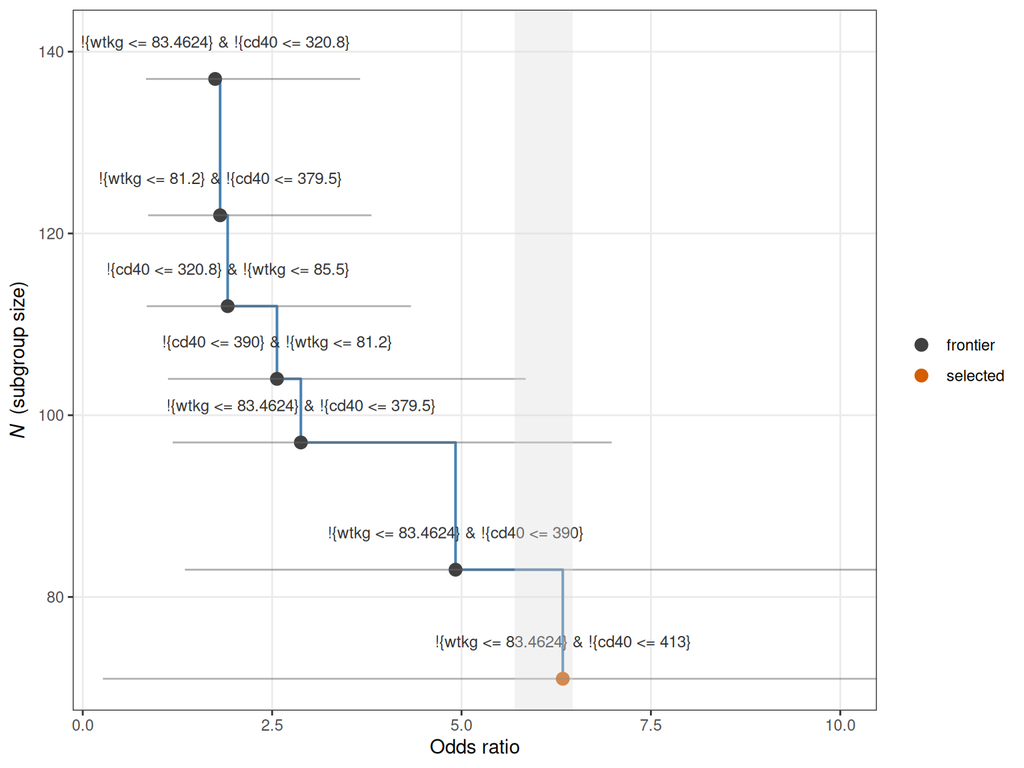

```r
# Formatted gt table; selected subgroup is highlighted and marked with ★.
# Works uniformly for survival (HR) and GLM (OR, RR, IRR, RD, IRD, MD)
# outcomes — effect-column label and scale derived from
# fs_result$effect_measure.  For OR, the effect column is exponentiated
# for display and the band test is on the natural OR scale.

# 1. Compute the CIs once (this is the expensive step, ~1-3 min).
#    Parameters come from frontier_params in the Analysis Configuration.
ci_tab <- compute_frontier_cis(
  fs_result,
  n_splits = frontier_params$n_splits,
  seed     = frontier_params$seed
)

# 2. Plot, with split-derived CI bars overlaid; same intervals as the table.
p_pareto <- plot_pareto_frontier(
  fs_result,
  ci_table  = ci_tab,
  show_band = TRUE,
  xlim      = frontier_params$xlim
)
print(p_pareto)
```

```r
# 3. Render the table. Pass the same ci_tab so the table and plot show
#    identical intervals.
pareto_frontier_table(
  fs_result,
  ci_table = ci_tab,
  digits   = frontier_params$digits
)
```

Pareto frontier on (OR, N)

7 non-dominated candidate(s) | sg_focus = 'hrMaxSG' | OR shown on natural scale (exponentiated from log-scale storage) | diagnostic only

| S<sup>1,2</sup> | M.1 | M.2 | N | E | OR | P<sup>3</sup> | K | 95% CIs Naive | 95% CIs Split ~ | 95% CIs FSBC ~ |
| --- | --- | --- | --- | --- | --- | --- | --- | --- | --- | --- |
| ★ | !{wtkg <= 83.4624} | !{cd40 <= 413} | 71 | 41 | 6.34 | 1.00 | 2 | (2.19, 18.37) | (0.27, 151.36) | 5.20 (0.22, 124.19) |
|  | !{wtkg <= 83.4624} | !{cd40 <= 390} | 83 | 44 | 4.92 | 1.00 | 2 | (1.93, 12.54) | (1.35, 17.96) | 4.64 (1.27, 16.94) |
|  | !{wtkg <= 83.4624} | !{cd40 <= 379.5} | 97 | 49 | 2.88 | 0.97 | 2 | (1.26, 6.57) | (1.19, 6.98) | 2.80 (1.16, 6.79) |
|  | !{cd40 <= 390} | !{wtkg <= 81.2} | 104 | 52 | 2.56 | 0.99 | 2 | (1.16, 5.65) | (1.12, 5.85) | 2.50 (1.10, 5.70) |
|  | !{cd40 <= 320.8} | !{wtkg <= 85.5} | 112 | 57 | 1.91 | 0.92 | 2 | (0.90, 4.05) | (0.84, 4.33) | 1.89 (0.83, 4.27) |
|  | !{wtkg <= 81.2} | !{cd40 <= 379.5} | 122 | 59 | 1.81 | 0.91 | 2 | (0.88, 3.72) | (0.86, 3.81) | 1.80 (0.86, 3.78) |
|  | !{wtkg <= 83.4624} | !{cd40 <= 320.8} | 137 | 65 | 1.75 | 0.95 | 2 | (0.89, 3.44) | (0.83, 3.66) | 1.73 (0.82, 3.62) |

<sup>1</sup> S: selected subgroup (winner of the configured selection rule).  
<sup>2</sup> ★ marks the subgroup chosen by sg_focus = 'hrMaxSG'.  
<sup>3</sup> P: Pcons (consistency probability).

### 5.8.1 Selection Narrative

`explain_pareto_selection()` describes the chosen subgroup relative to the non-dominated alternatives on the frontier. Under `effMaxSG` with `selection_rule = "both"`, the winner is a frontier member that also sits in the effect-size band; the “losers” are frontier candidates that fall outside the band (high-N candidates with weaker effect). The narrative names both the criterion and the runner-up.

```r
cat(explain_pareto_selection(fs_result, ci_table = ci_tab))
```

**Selection criterion.** The configured criterion is largest-N within the effect-size band (sg_focus = “hrMaxSG”) under the intersection of effect-band and Pareto-non-dominance rules. The effect-size band requires odds ratio within 10% of the maximum on the frontier (i.e., odds ratio >= 5.703). Within the eligible set, ties on N are broken by Pcons, then by effect strength, then by parsimony (smaller K).

**Selected subgroup.** !{wtkg <= 83.4624} AND !{cd40 <= 413} (odds ratio = 6.337, N = 71, Pcons = 1.000, K = 2). This is the largest-N candidate in the eligible set among non-dominated frontier candidates. The Naive 95% CI for the odds ratio on this subgroup is (2.186, 18.367).

**Non-selected frontier candidates** (ordered by closeness to winning):

- **!{wtkg <= 83.4624} AND !{cd40 <= 390}** (odds ratio = 4.921, N = 83, Pcons = 1.000, K = 2). fell outside the effect-size band (odds ratio = 4.921 below the floor); excluded before the N tiebreaker even applies.
- **!{wtkg <= 83.4624} AND !{cd40 <= 379.5}** (odds ratio = 2.879, N = 97, Pcons = 0.970, K = 2). fell outside the effect-size band (odds ratio = 2.879 below the floor); excluded before the N tiebreaker even applies.
- **!{cd40 <= 390} AND !{wtkg <= 81.2}** (odds ratio = 2.564, N = 104, Pcons = 0.990, K = 2). fell outside the effect-size band (odds ratio = 2.564 below the floor); excluded before the N tiebreaker even applies.
- **!{cd40 <= 320.8} AND !{wtkg <= 85.5}** (odds ratio = 1.913, N = 112, Pcons = 0.920, K = 2). fell outside the effect-size band (odds ratio = 1.913 below the floor); excluded before the N tiebreaker even applies.
- **!{wtkg <= 81.2} AND !{cd40 <= 379.5}** (odds ratio = 1.813, N = 122, Pcons = 0.910, K = 2). fell outside the effect-size band (odds ratio = 1.813 below the floor); excluded before the N tiebreaker even applies.
- **!{wtkg <= 83.4624} AND !{cd40 <= 320.8}** (odds ratio = 1.748, N = 137, Pcons = 0.950, K = 2). fell outside the effect-size band (odds ratio = 1.748 below the floor); excluded before the N tiebreaker even applies.

```r
# Programmatic access — two paths.

# (a) Frontier table with pre-formatted CI strings, one row per frontier
#     member.  CI columns ("Naive 95% CI", "Split ~ 95% CI",
#     "FSBC ~ 95% CI") are character strings like "(1.45, 2.87)".
pareto_frontier_table(
  fs_result,
  ci_table = ci_tab,
  format   = "data.table",
  digits   = frontier_params$digits
)

# (b) Rich post-consistency view: ALL passing candidates (not just the
#     frontier), with on_frontier and (where applicable) in_band flag
#     columns added.  Provides programmatic access to the same content
#     as the in-flight summary printed by forestsearch().
pareto_frontier_table(
  fs_result,
  ci_table          = ci_tab,
  include_dominated = TRUE,
  format            = "data.table",
  digits            = frontier_params$digits
)

# (c) Raw numeric CIs: keyed data.table with one row per frontier
#     member.  Same content as (a) but each bound is a numeric column
#     (naive_lcl, naive_ucl, split_lcl, split_ucl, fsbc_estimate,
#     fsbc_lcl, fsbc_ucl, plus split_sd and n_valid_splits).  This is
#     what step 1 of fs-pareto produced.
ci_tab
```

## 5.9 Bootstrap Bias Correction

Bootstrap bias correction adjusts the FS point estimate for the optimism inherent in data-driven subgroup identification. The bootstrap pipeline auto-detects the `OR` effect column from `fs_result` and produces bias-corrected OR estimates with bootstrap distributions and diagnostics.

**Note**

**Demo mode**: `NB = 20` for pressure-testing the pipeline end-to-end. Production runs should use `NB = 500–2000`. Set `run_bootstrap = FALSE` in the parameters chunk to skip this section entirely.

```r
t0 <- proc.time()

fs_bc <- forestsearch_bootstrap_dofuture(
  fs.est = fs_result,
  nb_boots = NB,
  show_three = FALSE,
  details = FALSE,
  digits = construction_digits,
  parallel_args = list(
    plan = "multisession",
    workers = n_cores,
    show_message = TRUE
  )
)
```

```
#> Bootstrap parallel config: Using user-provided settings
```

```
#> System max cores available: 128
```

```
#> Bootstrap will use: 121 workers with 'multisession' plan
```

```
#> Parallel plan: multisession with 121 workers.
```

```
#> Bootstrap iteration 1/20
```

```
#> Bootstrap iteration 10/20
```

```
#> Bootstrap iteration 20/20
```

```r
plan("sequential"); gc(verbose = FALSE)
```

```
#>           used  (Mb) gc trigger  (Mb) max used  (Mb)
#> Ncells 3272618 174.8    6142611 328.1  4776351 255.1
#> Vcells 8349923  63.8   28144770 214.8 23766506 181.4
```

```r
timings$bootstrap <- (proc.time() - t0)["elapsed"]

cat("\nBootstrap completed in", round(timings$bootstrap / 60, 2), "minutes",
    sprintf("(NB = %d, n_cores = %d)\n", NB, n_cores))
```

```
#>
#> Bootstrap completed in 0.72 minutes (NB = 20, n_cores = 121)
```

### 5.9.1 Bootstrap Summary

```r
# Note: est.scale only affects the legacy HR-flavored caption helper; the
# OR column (with bias-corrected OR*) is auto-detected from FSsg_tab.
fs_summaries <- summarize_bootstrap_results(
  sgharm       = fs_result$sg.harm,
  boot_results = fs_bc,
  create_plots = TRUE,
  est.scale    = "hr",
  digits       = display_digits
)
```

```
#>
#> ===============================================================
#>            BOOTSTRAP ANALYSIS SUMMARY
#> ===============================================================
#>
#> IDENTIFIED SUBGROUP:
#> -------------------------------------------------------------
#>   H: !{wtkg <= 83.4624} & !{cd40 <= 413}
#>
#> BOOTSTRAP SUCCESS METRICS:
#> -------------------------------------------------------------
#>   Total iterations:              20
#>   Successful subgroup ID:        20 (100.0%)
#>   Failed to find subgroup:       0 (0.0%)
#>
#> TIMING ANALYSIS:
#> -------------------------------------------------------------
#> Overall:
#>   Total bootstrap time:          0.68 minutes (0.01 hours)
#>   Average per iteration:         0.03 min (2.0 sec)
#>   Projected for 1000 boots:      33.86 min (0.56 hrs)
```

```r
fs_summaries$table
```

**Treatment Effect by Subgroup**

Bootstrap bias-corrected estimates (20 iterations)

| Subgroup | Sample Size N | Sample Size N<sub>T</sub> | Event Rates Rate<sub>C</sub> | Event Rates Rate<sub>T</sub> | Diff | Treatment Effect OR (95% CI)†<sup>1</sup> | Treatment Effect OR‡ (95% CI)<sup>2</sup> |
| --- | --- | --- | --- | --- | --- | --- | --- |
| Qstnbl<sup>3</sup> | 71 (6.6%) | 34 (47.9%) | 37.84% | 79.41% | +41.57% | 6.34 (2.19, 18.37) | 4.38 (1.05,18.33) |
| Recmnd | 1012 (93.4%) | 488 (48.2%) | 44.85% | 31.56% | -13.29% | 0.57 (0.44, 0.73) | 0.57 (0.05,6.35) |

<sup>1</sup> **Unadjusted OR**: GLM estimate with robust standard errors  
<sup>2</sup> **Bias-corrected OR**: Bootstrap-adjusted estimate using infinitesimal jackknife method (20 iterations). Corrects for optimism in subgroup selection.  
<sup>3</sup> **Identified subgroup**: !{wtkg <= 83.4624} & !{cd40 <= 413}  
*Note*: Rate<sub>C</sub> = control arm event rate; Rate<sub>T</sub> = treatment arm event rate. Subgroup identified in 100.0% of bootstrap samples.

### 5.9.2 Bootstrap Diagnostics

```r
fs_summaries$diagnostics_table_gt
```

**Bootstrap Diagnostics Summary**

Analysis of 20 bootstrap iterations

| Category | Metric | Value |
| --- | --- | --- |
| Success Rate | Total iterations | 20 |
|  | Successful | 20 (100.0%) |
|  | Failed | 0 (0.0%) |
|  | Success rating | Excellent |
| Subgroup H (Questionable) | Observed OR | 6.337 |
|  | Bias-corrected OR | 4.380 |
|  | Bootstrap CV (%) | 38.5% |
|  | N estimates | 20 |
| Subgroup Hc (Recommend) | Observed OR | 0.567 |
|  | Bias-corrected OR | 0.573 |
|  | Bootstrap CV (%) | 31.1% |
|  | N estimates | 20 |

### 5.9.3 Subgroup Agreement

```r
if (!is.null(fs_summaries$subgroup_summary$original_agreement)) {
  fs_summaries$subgroup_summary$original_agreement
}
```

```
#>                             Metric                               Value
#>                             <char>                              <char>
#> 1:      Total bootstrap iterations                                  20
#> 2:           Successful iterations                                  20
#> 3: Failed iterations (no subgroup)                                   0
#> 4:
#> 5:    Original subgroup definition !{cd40 <= 413} & !{wtkg <= 83.4624}
#> 6:       Exact match with original                            0 (0.0%)
#> 7:         Different from original                         20 (100.0%)
#> 8:   Partial match (shared factor)                            0 (0.0%)
```

```r
if (!is.null(fs_summaries$subgroup_summary$factor_presence)) {
  fs_summaries$subgroup_summary$factor_presence
}
```

```
#>   Rank  Factor Count Percent
#> 2    1    cd40    13      65
#> 5    2 preanti     8      40
#> 6    3    wtkg     8      40
#> 3    4    cd80     7      35
#> 1    5     age     3      15
#> 4    6  karnof     1       5
```

### 5.9.4 Bootstrap Distributions

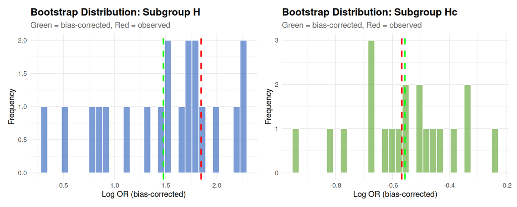

Bootstrap distributions of OR for H (questionable) and Hc (recommend)

```r
if (!is.null(fs_summaries$plots)) {
  fs_summaries$plots$H_distribution + fs_summaries$plots$Hc_distribution
}
```

## 5.10 Cross-Validation

K-fold cross-validation assesses the **stability** of the FS pipeline by re-running ForestSearch on each leave-out fold and comparing the identified subgroup to the full-data analysis. Per-fold results are aggregated into agreement metrics (sensitivity for H and Hc) and finding rates.

**Note**

```r
t0 <- proc.time()

fs_kfold_result <- forestsearch_Kfold(
  fs.est        = fs_result,
  Kfolds        = Kfolds_cv,
  seedit        = analysis_seed,
  parallel_args = list(
    plan = "multisession",
    workers = n_cores,
    show_message = TRUE
  ),
  details       = FALSE
)
```

```
#> Parallel plan: multisession with 121 workers.
```

```r
plan("sequential"); gc(verbose = FALSE)
```

```
#>           used  (Mb) gc trigger  (Mb) max used  (Mb)
#> Ncells 3369766 180.0    6142611 328.1  6142611 328.1
#> Vcells 8564664  65.4   28144770 214.8 23766506 181.4
```

```r
timings$cv <- (proc.time() - t0)["elapsed"]

cat("\nCross-validation completed in", round(timings$cv / 60, 2), "minutes",
    sprintf("(Kfolds = %d, n_cores = %d)\n", Kfolds_cv, n_cores))
```

```
#>
#> Cross-validation completed in 0.23 minutes (Kfolds = 3, n_cores = 121)
```

### 5.10.1 CV Summary

```r
# One-line summary: finding rate + agreement
cat(cv_summary_text(fs_kfold_result, est.scale = "hr"), "\n")
```

```
#> CV found = 100%, Agree(+,-) = 98%, 100%
```

```r
cat(sprintf("Subgroup found in %.0f%% of %d folds.\n",
            100 * fs_kfold_result$prop_SG_found, Kfolds_cv))
```

[output not shown]

### 5.10.2 CV Tables

```r
kfold_out <- forestsearch_KfoldOut(fs_kfold_result, outall = TRUE,
                                   digits = construction_digits)
cv_tabs   <- cv_summary_tables(
  kfold_out,
  title    = "ACTG175 Cross-Validation Summary (Binary, OR)",
  subtitle = sprintf("ITT and Subgroup Estimates: Full Analysis (FA) vs %d-fold (Kf)",
                     Kfolds_cv),
  digits   = display_digits,
  use_gt   = TRUE
)

cv_tabs$combined_table
```

**ACTG175 Cross-Validation Summary (Binary, OR)**

ITT and Subgroup Estimates: Full Analysis (FA) vs 3-fold (Kf)

| Analysis | Subgroup | n | n1 | Rate(C) | Rate(T) | Diff | OR |
| --- | --- | --- | --- | --- | --- | --- | --- |
| Overall | ITT | 1083 (100.0%) | 522 (48.2%) | 44.39% | 34.67% | -9.71% | 0.67 (0.52, 0.85) |
| FA_0 | Not recommend | 71 (6.6%) | 34 (47.9%) | 37.84% | 79.41% | +41.57% | 6.34 (2.19, 18.37) |
| KfA_0 | Not recommend | 96 (8.9%) | 47 (49.0%) | 38.78% | 61.70% | +22.93% | 2.54 (1.12, 5.79) |
| FA_1 | Recommend | 1012 (93.4%) | 488 (48.2%) | 44.85% | 31.56% | -13.29% | 0.57 (0.44, 0.73) |
| KfA_1 | Recommend | 987 (91.1%) | 475 (48.1%) | 44.92% | 32.00% | -12.92% | 0.58 (0.44, 0.75) |

FA = Full Analysis (original data), Kf = K-fold CV estimate

### 5.10.3 CV Agreement Metrics

```r
if (!is.null(cv_tabs$metrics_table)) {
  cv_tabs$metrics_table
}
```

**Cross-Validation Metrics**

Agreement and subgroup finding rates (%)

| Metric | Value (%) |
| --- | --- |
| Agreement |  |
| Sensitivity (H) | 100.00 |
| Sensitivity (Hc) | 97.53 |
| PPV (H) | 73.96 |
| PPV (Hc) | 100.00 |
| Finding |  |
| Any Found | 100.00 |
| Exact Match | 0.00 |
| At Least 1 | 33.33 |
| Cov1 Any | 100.00 |
| Cov2 Any | 100.00 |
| Cov1 & Cov2 | 100.00 |
| Cov1 Exact | 33.33 |
| Cov2 Exact | 0.00 |

## 5.11 Leave-One-Out Cross-Validation

Leave-one-out (LOO) cross-validation is the limiting case of K-fold CV where each observation is held out once. It is the most thorough form of CV, eliminating fold-assignment randomness, and is the appropriate benchmark when sample size is small enough to make `N` re-fits tractable.

**Note**

**Cost**: LOO runs `forestsearch()` once per observation. Toggleable independently from K-fold via `run_loo` in the parameters chunk. On samples up to roughly 1000 the cost is well-tolerated with parallel workers; beyond that, K-fold is preferred.

```r
t0 <- proc.time()

# LOO is triggered by Kfolds = N (the function default behavior at
# forestsearch_cross_validation.R:109).  We pass it explicitly here for
# clarity.
N_loo <- nrow(fs_result$df.est)

fs_loo_result <- forestsearch_Kfold(
  fs.est        = fs_result,
  Kfolds        = N_loo,
  seedit        = analysis_seed,
  parallel_args = list(
    plan = "multisession",
    workers = n_cores,
    show_message = TRUE
  ),
  details       = FALSE
)

plan("sequential"); gc(verbose = FALSE)
timings$loo <- (proc.time() - t0)["elapsed"]

cat("\nLOO completed in", round(timings$loo / 60, 2), "minutes",
    sprintf("(N folds = %d, n_cores = %d)\n", N_loo, n_cores))
```

### 5.11.1 LOO Summary

```r
cat(cv_summary_text(fs_loo_result, est.scale = "hr"), "\n")
cat(sprintf("Subgroup found in %.0f%% of %d folds.\n",
            100 * fs_loo_result$prop_SG_found, N_loo))
```

### 5.11.2 LOO Tables

The `cv_summary_tables()` helper returns five publication-ready `gt` tables. The first is the combined ITT + subgroup view; the next three are component estimation tables (ITT, full-analysis subgroup, LOO subgroup) that show the underlying treatment-effect estimates with confidence intervals.

```r
loo_out  <- forestsearch_KfoldOut(fs_loo_result, outall = TRUE,
                                  digits = construction_digits)
loo_tabs <- cv_summary_tables(
  loo_out,
  title    = "ACTG175 Leave-One-Out CV Summary (Binary, OR)",
  subtitle = sprintf("ITT and Subgroup Estimates: Full Analysis (FA) vs LOO (N=%d)",
                     N_loo),
  digits   = display_digits,
  use_gt   = TRUE
)
```

#### 5.11.2.1 Combined Table (ITT + Subgroup)

```r
loo_tabs$combined_table
```

#### 5.11.2.2 ITT Estimation Table

```r
if (!is.null(loo_tabs$itt_table)) {
  loo_tabs$itt_table
} else {
  cat("ITT estimation table not available.\n")
}
```

#### 5.11.2.3 Subgroup Estimation Table — Full Analysis

```r
if (!is.null(loo_tabs$original_table)) {
  loo_tabs$original_table
} else {
  cat("Full-analysis subgroup estimation table not available.\n")
}
```

#### 5.11.2.4 Subgroup Estimation Table — LOO

```r
# Note: cv_summary_tables labels the CV-fold table "K-fold" internally
# (cv_summary_tables.R:200-218); for LOO this slot holds the per-fold
# LOO subgroup estimates.
if (!is.null(loo_tabs$kfold_table)) {
  loo_tabs$kfold_table
} else {
  cat("LOO subgroup estimation table not available.\n")
}
```

### 5.11.3 LOO Agreement Metrics

```r
if (!is.null(loo_tabs$metrics_table)) {
  loo_tabs$metrics_table
}
```

## 5.12 Combined Forest Plot

```r
# Build fs_results list dynamically based on what's been computed.
fs_results_list <- list(fs.est = fs_result)

if (exists("fs_bc")) {
  fs_results_list$fs_bc <- fs_bc
}
# Forest plot accepts one CV source in the fs_kfold slot.  Prefer
# K-fold; fall back to LOO if K-fold wasn't run but LOO was.
cv_label_for_plot <- NULL
if (exists("fs_kfold_result")) {
  fs_results_list$fs_kfold <- fs_kfold_result
  cv_label_for_plot <- sprintf("%d-fold CV", Kfolds_cv)
} else if (exists("fs_loo_result")) {
  fs_results_list$fs_kfold <- fs_loo_result
  cv_label_for_plot <- "LOO CV"
}

# For binary outcomes, event.name = outcome.name (the binary indicator is
# its own event).  xlog = TRUE for OR (ratio scale, log axis).
forest_obj <- plot_subgroup_results_forestplot(
  fs_results     = fs_results_list,
  df_analysis    = actg_df,
  outcome.name   = adverse_outcome,
  event.name     = adverse_outcome,
  treat.name     = treat.name,
  E.name         = "ZDV+ddI",
  C.name         = "ddI",
  outcome_type   = fs_outcome_type,
  effect_measure = fs_effect_measure,
  xlog           = TRUE,                 # OR is ratio scale -> log axis
  arrow_text     = c("Favors ZDV+ddI", "Favors ddI"),
  title_text     = "ACTG175 Subgroup Results — Binary (OR, adverse scale)",
  show_cv_metrics = !is.null(cv_label_for_plot),
  cv_source      = "kfold",
  xlim_method    = "data"
)
```

```
#> refline_lwd, refline_lty, refline_col will be deprecated, use refline_gp instead.
```

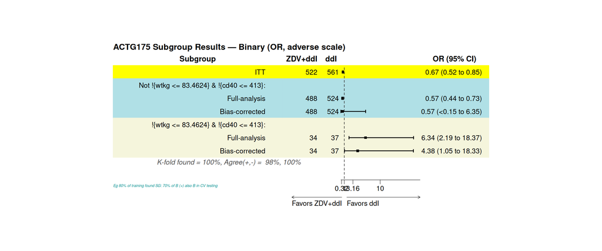

Forest plot of ITT and identified subgroup; OR on the adverse scale (no improvement)

```r
render_forestplot(forest_obj)
```

```r
if (!is.null(cv_label_for_plot)) {
  cat(sprintf("\nCV annotations source: %s.\n", cv_label_for_plot))
}
```

```
#>
#> CV annotations source: 3-fold CV.
```

# 6 Part II: GRF Standalone (Beneficial Scale)

## 6.1 Rationale

GRF operates on the beneficial scale (`y_binary_pos`, indicator of CD4 improvement) with `adverse_outcome = FALSE` (the default). A negative CATE means the treatment **decreases the probability of improvement** in that subgroup — harm via insufficient benefit. This is the natural complement to the FS analysis on the adverse scale: same outcome data, opposite encoding, and a different model class (causal forest with policy-tree subgroup extraction).

For binary outcomes the per-subject CATE from `grf::causal_forest()` is on the **risk-difference (RD) scale**: \(\widehat{\tau}_i = \hat{P}(Y_i=1 \mid T=1, X_i) - \hat{P}(Y_i=1 \mid T=0, X_i)\), bounded in \([-1, 1]\). The `dmin.grf` threshold is interpreted on this same RD scale (e.g., `dmin.grf = 0.10` requires at least a 10 percentage-point absolute difference in event rates). The effect-measure label `"OR"` controls how the FS-side estimation and reporting step renders the subgroup contrast; the GRF CATE itself remains on the RD scale internally.

## 6.2 Running GRF

```r
t0 <- proc.time()

grf_result <- grf.subg.harm.glm(
  data             = actg_df,
  confounders.name = confounders.name,
  outcome.name     = beneficial_outcome,
  treat.name       = treat.name,
  id.name          = id.name,
  outcome_type     = grf_outcome_type,
  effect_measure   = grf_effect_measure,
  dmin.grf         = grf_dmin_grf,
  maxdepth         = grf_maxdepth,
  RCT              = grf_RCT,
  sg.criterion     = grf_sg_criterion,
  details          = TRUE
)

timings$grf <- (proc.time() - t0)["elapsed"]
cat("\nGRF (beneficial scale) completed in",
    round(timings$grf, 1), "seconds\n")
```

```
#>
#> GRF (beneficial scale) completed in 0.3 seconds
```

## 6.3 Policy Trees

```r
if (!is.null(grf_result$trees)) {
  oldpar <- par(mfrow = c(1, 2))
  if (length(grf_result$trees) >= 1 && !is.null(grf_result$trees[[1]])) {
    plot(grf_result$trees[[1]],
         leaf.labels = c("Control", "Treat"), main = "Depth 1")
  }
  if (length(grf_result$trees) >= 2 && !is.null(grf_result$trees[[2]])) {
    plot(grf_result$trees[[2]],
         leaf.labels = c("Control", "Treat"), main = "Depth 2")
  }
  par(oldpar)
} else {
  cat("GRF: no policy trees available.\n")
}
```

[output not shown]

## 6.4 Identified Subgroup Definition

```r
if (!is.null(grf_result$sg.harm.id) && length(grf_result$sg.harm.id) > 0) {
  grf_H <- grf_result$data$treat.recommend == 0
  cat("Identified subgroup (H, GRF beneficial):",
      paste(grf_result$sg.harm.id, collapse = " & "), "\n")
  cat(sprintf("Subgroup size: %d (%.1f%% of ITT)\n",
              sum(grf_H), 100 * mean(grf_H)))
  cat(sprintf("CATE(H):  %+6.3f  (RD: P(improve|T=1) - P(improve|T=0) in H)\n",
              grf_result$cate_sg))
  cat(sprintf("CATE(Hc): %+6.3f\n", grf_result$cate_sgc))
} else {
  cat("GRF: no subgroup identified.\n")
}
```

```
#> Identified subgroup (H, GRF beneficial): wtkg <= 83.46 & preanti <= 1292 & cd40 <= 390
#> Subgroup size: 130 (12.0% of ITT)
#> CATE(H):  -0.337  (RD: P(improve|T=1) - P(improve|T=0) in H)
#> CATE(Hc): +0.165
```

## 6.5 GRF Variable Importance

GRF reports per-covariate variable importance from the causal forest, quantifying each covariate’s contribution to splitting decisions in the treatment-effect estimation. Higher values indicate stronger influence on detected heterogeneity. Note this differs from prediction-importance in standard random forests; here it reflects relevance to **CATE estimation**, not to the marginal outcome.

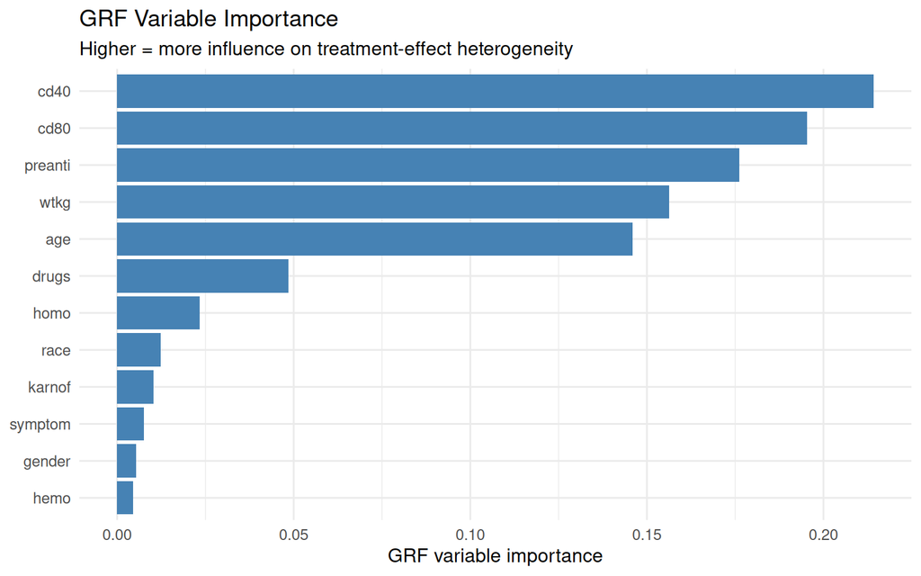

GRF variable importance from the causal forest

```r
if (!is.null(grf_result$grf_varimp) && length(grf_result$grf_varimp) > 0) {
  vi <- grf_result$grf_varimp
  vi_df <- data.frame(
    variable   = names(vi),
    importance = unname(vi)
  )
  # Order ascending so largest appears at top after coord_flip()
  vi_df <- vi_df[order(vi_df$importance), ]
  vi_df$variable <- factor(vi_df$variable, levels = vi_df$variable)

  ggplot(vi_df, aes(x = variable, y = importance)) +
    geom_col(fill = "steelblue") +
    coord_flip() +
    labs(
      x        = NULL,
      y        = "GRF variable importance",
      title    = "GRF Variable Importance",
      subtitle = "Higher = more influence on treatment-effect heterogeneity"
    )
} else {
  cat("GRF variable importance not available.\n")
}
```

## 6.6 CATE Distribution

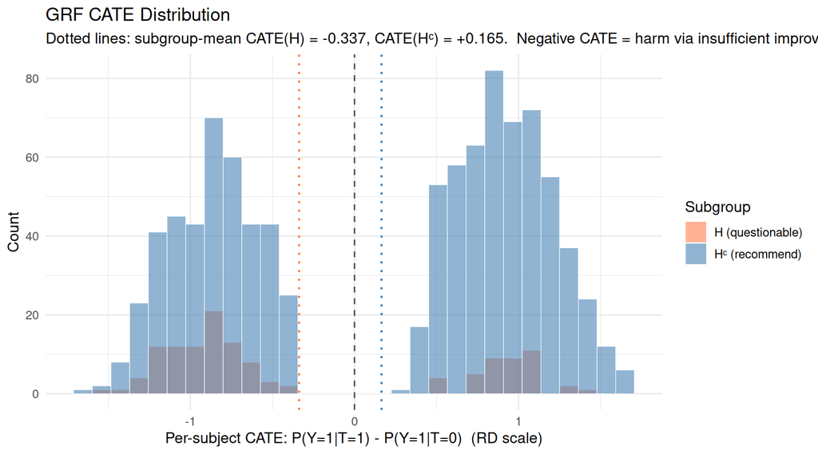

Per-subject CATE distribution from GRF, colored by H / Hc membership

```r
if (!is.null(grf_result$dr_scores) &&
    !is.null(grf_result$data$treat.recommend)) {

  cate_per_subject <- grf_result$dr_scores[, 2L] -
                      grf_result$dr_scores[, 1L]
  group_label <- ifelse(grf_result$data$treat.recommend == 0,
                        "H (questionable)",
                        "H\u1d9c (recommend)")
  cate_df <- data.frame(
    cate  = cate_per_subject,
    group = factor(group_label,
                   levels = c("H (questionable)", "H\u1d9c (recommend)"))
  )

  ggplot(cate_df, aes(x = cate, fill = group)) +
    geom_histogram(alpha = 0.6, position = "identity", bins = 30,
                   color = "white", linewidth = 0.2) +
    geom_vline(xintercept = 0, linetype = "dashed", color = "grey30") +
    geom_vline(xintercept = grf_result$cate_sg,
               linetype = "dotted", color = "coral", linewidth = 0.8) +
    geom_vline(xintercept = grf_result$cate_sgc,
               linetype = "dotted", color = "steelblue", linewidth = 0.8) +
    scale_fill_manual(values = c(
      "H (questionable)"     = "coral",
      "H\u1d9c (recommend)"  = "steelblue"
    )) +
    labs(
      x        = "Per-subject CATE: P(Y=1|T=1) - P(Y=1|T=0)  (RD scale)",
      y        = "Count",
      title    = "GRF CATE Distribution",
      subtitle = paste0("Dotted lines: subgroup-mean CATE(H) = ",
                        sprintf("%+.3f", grf_result$cate_sg),
                        ", CATE(H\u1d9c) = ",
                        sprintf("%+.3f", grf_result$cate_sgc),
                        ".  Negative CATE = harm via insufficient improvement."),
      fill     = "Subgroup"
    )
} else {
  cat("GRF DR-scores or treat.recommend not available.\n")
}
```

## 6.7 Treatment Effect Estimates

```r
grf_tabs <- sg_tables(grf_result, ndecimals = display_digits, which_df = "est")
grf_tabs$tab_estimates
```

**Treatment Effect Estimates**

Training data estimates

| Subgroup | n | n1 | Rate(C) | Rate(T) | Diff | OR (95% CI) |
| --- | --- | --- | --- | --- | --- | --- |
| ITT | 1083 (100.0%) | 522 (48.2%) | 55.61% | 65.33% | +9.71% | 1.50 (1.18, 1.92) |
| Questionable<sup>1</sup> | 130 (12.0%) | 59 (45.4%) | 67.61% | 30.51% | -37.10% | 0.21 (0.10, 0.44) |
| Recommend | 953 (88.0%) | 463 (48.6%) | 53.88% | 69.76% | +15.88% | 1.98 (1.51, 2.58) |

<sup>1</sup> **Identified subgroup (GRF):** wtkg <= 83.46 & preanti <= 1292 & cd40 <= 390  
**GRF CATE:** Ĥ = -0.3375, Ĥ<sup>c</sup> = 0.1647 (risk-difference scale)

## 6.8 Subgroup Outcome Visualization

```r
# plot_sg_glm_outcomes() expects an fs.est-shaped object with df.est and
# sg.harm.  GRF returns `data` and `sg.harm.id`, so we wrap them in a
# minimal shim list.  All other arguments are passed explicitly so no
# auto-detection from the shim is required.
grf_shim <- list(
  df.est         = grf_result$data,
  outcome_type   = grf_result$outcome_type,
  effect_measure = grf_result$effect_measure,
  sg.harm        = grf_result$sg.harm.id
)

grf_plot <- plot_sg_glm_outcomes(
  fs.est         = grf_shim,
  outcome.name   = beneficial_outcome,
  treat.name     = treat.name,
  effect_measure = grf_effect_measure,
  outcome_type   = grf_outcome_type,
  E.name         = "ZDV+ddI",
  C.name         = "ddI",
  show_itt       = TRUE,
  show_effect    = TRUE,
  verbose        = TRUE
)
```

```
#> ℹ Adding new coordinate system, which will replace the existing one.
```

```
#> Figure note: Identified subgroup (H): wtkg <= 83.46 & preanti <= 1292 & cd40 <= 390. Bars show event rates per arm; error bars show 95 percent CI.
```

# 7 Part III: Cross-Method Comparison

The two analyses define H differently:

- FS uses the adverse scale (`y_binary_neg`, `OR > c1` = harm).
- GRF uses the beneficial scale (`y_binary_pos`, CATE below 0 = harm).

Both classify subjects as H (`treat.recommend == 0`) when they meet their respective harm criterion, so per-subject membership is directly comparable. The cross-tabulation below reports raw agreement and Cohen’s κ.

```r
sg_comparison <- compare_fs_subgroups(
  fs1     = fs_result,
  fs2     = grf_result,
  label1  = "FS (adverse)",
  label2  = "GRF (beneficial)",
  id.name = id.name,
  subgroup_notation = "harm",
  title   = "FS-Adverse vs GRF-Beneficial: Subgroup Membership"
)

sg_comparison$table
```

**FS-Adverse vs GRF-Beneficial: Subgroup Membership**

FS (adverse): !{wtkg <= 83.4624} & !{cd40 <= 413} vs. GRF (beneficial): wtkg <= 83.46 & preanti <= 1292 & cd40 <= 390

[output not shown]

**Agreement:** 1024 / 1083 (94.6%) **Cohen’s κ:** 0.679 **FS (adverse) H:** !{wtkg <= 83.4624} & !{cd40 <= 413} **GRF (beneficial) H:** wtkg <= 83.46 & preanti <= 1292 & cd40 <= 390

```r
cat("=== Concordance summary ===\n")
```

```
#> === Concordance summary ===
```

```r
cat(sprintf("Agreement:    %.1f%%\n",
            100 * sg_comparison$concordance$agreement))
```

```
#> Agreement:    94.6%
```

```r
if (!is.null(sg_comparison$concordance$kappa)) {
  cat(sprintf("Cohen's kappa: %.3f\n",
              sg_comparison$concordance$kappa))
}
```

```
#> Cohen's kappa: 0.679
```

# 8 Computational Timing

```r
timings$total <- (proc.time() - t_vignette_start)["elapsed"]

components <- c("ForestSearch (adverse)", "GRF (beneficial)")
seconds    <- c(timings$fs,             timings$grf)

if (run_bootstrap && !is.null(timings$bootstrap)) {
  components <- c(components, "Bootstrap (FS)")
  seconds    <- c(seconds,    timings$bootstrap)
}

if (run_cv && !is.null(timings$cv)) {
  components <- c(components, "Cross-Validation (FS)")
  seconds    <- c(seconds,    timings$cv)
}

if (run_loo && !is.null(timings$loo)) {
  components <- c(components, "Leave-One-Out CV (FS)")
  seconds    <- c(seconds,    timings$loo)
}

components <- c(components, "Total")
seconds    <- c(seconds,    timings$total)

timing_df <- data.frame(
  Analysis = components,
  Seconds  = unname(seconds),
  Minutes  = unname(seconds) / 60
)

gt(timing_df) |>
  tab_header(title = "Computational Timing") |>
  fmt_number(columns = c(Seconds, Minutes), decimals = 2) |>
  cols_label(
    Analysis = "Component",
    Seconds  = "Time (sec)",
    Minutes  = "Time (min)"
  )
```

Computational Timing

| Component | Time (sec) | Time (min) |
| --- | --- | --- |
| ForestSearch (adverse) | 45.56 | 0.76 |
| GRF (beneficial) | 0.28 | 0.00 |
| Bootstrap (FS) | 43.25 | 0.72 |
| Cross-Validation (FS) | 13.53 | 0.23 |
| Total | 126.33 | 2.11 |

# 9 References

León LF, Jemielita T, Guo Z, Marceau West R, Anderson KM (2024). “Exploratory subgroup identification in the heterogeneous Cox model: A relatively simple procedure.” *Statistics in Medicine*. DOI: 10.1002/sim.10163

Hammer SM, Katzenstein DA, Hughes MD, et al. (1996). A trial comparing nucleoside monotherapy with combination therapy in HIV-infected adults with CD4 cell counts from 200 to 500 per cubic millimeter. AIDS Clinical Trials Group Study 175 Study Team. *N Engl J Med*. 335(15):1081-90.